# DAKD 2024 EXERCISE 3: UNSUPERVISED LEARNING

### *** FILL YOUR INFORMATION BELOW ***

#### General Guidance for Exercises

- **Complete all tasks**: Make sure to answer all questions, even if you cannot get your script to fully work.
- **Code clarity**: Write clear and readable code. Include comments to explain what your code does.
- **Effective visualizations**: Ensure all plots have labeled axes, legends, and captions. Your visualizations should clearly represent the underlying data.
- **Notebook organization**: You can add more code or markdown cells to improve the structure of your notebook as long as it maintains a logical flow.
- **Submission**: Submit both the `.ipynb` and `.html` or `.pdf` versions of your notebook. Before finalizing your notebook, use the "Restart & Run All" feature to ensure it runs correctly.
- **Grading criteria**:
  - The grading scale is *Fail/Pass/Pass with honors* (+1).
  - To pass, you must complete the required parts 0-3.
  - To achieve *Pass with honors*, complete the bonus exercises.
- **Technical issues**:
  - If you encounter problems, start with an online search to find solutions but do not simply copy and paste code. Understand any code you use and integrate it appropriately.
  - Cite all external sources used, whether for code or explanations.
  - If problems persist, ask for help in the course discussion forum, at exercise sessions, or via email at konsta.k.nyman@utu.fi or antti.s.vasankari@utu.fi.
- **Use of AI and large language models**:
  - We do not encourage the use of AI tools like ChatGPT. If you use them, critically evaluate their outputs.
  - Describe how you used the AI tools in your work, including your input and how the output was beneficial.
- **Time management**: Do not leave your work until the last moment. No feedback will be available during weekends.

**Additional Notes**:

- You can find the specific deadlines and session times for each assignment on the Moodle course page.
- Ensure all your answers are concise—typically a few sentences per question.
- Your .ipynb notebook is expected to be run to completion, which means that it should execute without errors when all cells are run in sequence.

#### Exercise instructions

This is the template for the third exercise. The purpose of this exercise is to familiarize yourself with the basics of unsupervised learning by using the agglomerative hierarchical clustering and k-means clustering algorithms to find patterns.

This exercise uses the seeds dataset, available on moodle as `seeds.csv`. The features are all numeric. They quantify the measurements related to the geometrical properties of wheat grains. The feature names are listed in the table below.

| Feature | Type | :--- | ---: | Area | Numeric (float) | Perimeter | Numeric (float) | Compactness | Numeric (float) | Length | Numeric (float) | Width | Numeric (float) | Asymmetry Coefficient | Numeric (float) | Length Groove | Numeric (float)

In real applications, visualizing various aspects of the data the data and data scrubbing are important steps. However, in this exercise you can treat the data as given, and focus on the unsupervised methods. **REMEMBER, this step can never be neglected in the real world.**

#### Library imports, Jupyter Notebook settings etc.

The below libraries are sufficient to complete the exercise. You can import additional modules here if you want.

```python
import itertools # has some utilities that may be useful in the exercise

import numpy as np
import pandas as pd
import matplotlib.pyplot as plt
from matplotlib.patches import Ellipse
from sklearn.preprocessing import StandardScaler
from sklearn.decomposition import PCA
from sklearn.cluster import AgglomerativeClustering, KMeans
from sklearn.metrics import silhouette_score, adjusted_rand_score
from sklearn.decomposition import PCA

# IPython magic command to display matplotlib figures together with the output
# (Often the default setting in a Jupyter Notebook context, so your figures probably work fine without it)
%matplotlib inline
```

### Part 0: Read the data

- Download the exercise 3 data on the **Moodle** page of this course. (`seeds.csv`)
- Read the data into a Pandas dataframe.
- Display a few rows and some basic information to make sure the data was loaded correctly

```python
# YOUR CODE
seeds = pd.read_csv('seeds.csv')
print(seeds.head())
```

```
    area  perimeter  compactness  length  width  asymmetry_coef  length_groove
0  18.45      16.12       0.8921   6.107  3.769           2.235          5.794
1  11.41      12.95       0.8560   5.090  2.775           4.957          4.825
2  10.79      12.93       0.8107   5.317  2.648           5.462          5.194
3  18.14      16.12       0.8772   6.059  3.563           3.619          6.011
4  15.38      14.90       0.8706   5.884  3.268           4.462          5.795
```

### Part 1: Preprocess and visualize the data

- Perform z-score standardization on the features to ensure that all features have the same scale.
- Explain briefly why this is important.
- For visualization, project the data to two dimensions by using principal component analysis (PCA).
- **These PCs are solely used for plotting the data.** The clusterings are done on the original standardized features.

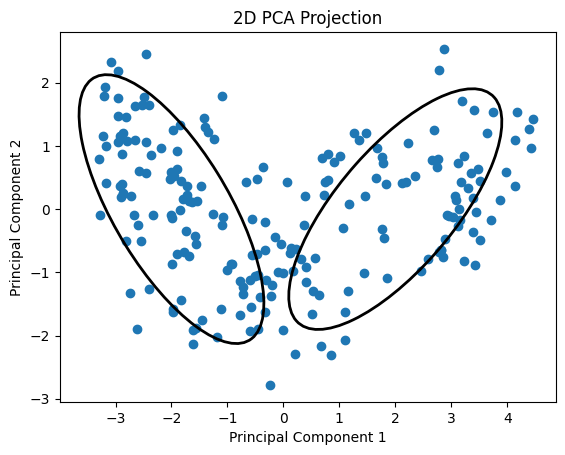

```python
# YOUR CODE
#Z-score standardization for dataframe
seeds_standardized = (seeds - seeds.mean()) / seeds.std()
#print(seeds_standardized)

#Fit to pca model with 2 components for 2d visualization
pca = PCA(n_components = 2)
seeds_2D = pca.fit_transform(seeds_standardized)

#Visualize with scatter plot
plt.scatter(seeds_2D[:, 0], seeds_2D[:, 1])

#Draw some ellipsies for fun
ax = plt.gca()
ellipse1 = Ellipse(xy = (-2, 0), height = 2, width = 5, angle = 305, edgecolor = 'black', facecolor = 'none', linewidth = 2)
ellipse2 = Ellipse(xy = (2, 0), height = 2, width = 5, angle = 45, edgecolor = 'black', facecolor = 'none', linewidth = 2)
ax.add_patch(ellipse1)
ax.add_patch(ellipse2)
plt.xlabel('Principal Component 1')
plt.ylabel('Principal Component 2')
plt.title('2D PCA Projection')
plt.show()
```

Standardizing the values in the dataframe is important for the principal component analysis to work, since pca is very sensitive towards variance.

- Visualize the resulting two-dimensional data in a scatter plot.
- Does it look like there are clear clusters? Don't worry if they're hard to see. There may be more than one "correct" answer.
- Draw shapes (for example `matplotlib.patches.Ellipse`) on top of the scatter plot to visualize any clusters you feel you can easily detect.

The scatter plot doesn't make it look like there's any clear separate clusters, though if there were 2 elliptic-shaped clusters that overlapped at the bottom it would like a the kind of "heart"-figure seen in the cluster. To make clusters more visible you usually want to plot a categorical variable with color, i.e. gender or sex.

### Part 2a: Agglomerative hierarchical clustering theory

Explain briefly the different linkage criterion values.

- Single: Single linkage represents the shortest distance between two clusters
- Average: Average linkage represents the average dissimilarity of data points of two clusters
- Complete: Complete linkage represents the longest distance between two clusters
- Ward: Ward's method uses squared euclidian distance to compute cluster distances

Explain the **silhouette coefficient** (silhouette_score).

The silhoutte value of a data point is a real number between -1 and +1 assigned to a data point which represents how well the point fits into the cluster it's a member of. The silhoutte coefficient (or score) is the mean of the silhoutte values for all data points in a dataset.

[output not shown]

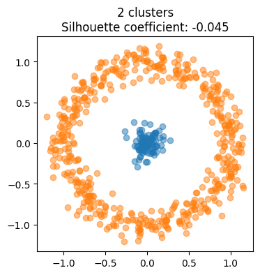

```python
n = 2
no_in = 100
no_out = 500
labels = np.concatenate((np.zeros(no_in), np.ones(no_out)))

inner_cluster = np.random.randn(no_in, 2)*0.1
theta = np.linspace(0, 2*np.pi, no_out)
outer_cluster = np.array([np.cos(theta), np.sin(theta)]).T + np.random.randn(no_out, 2)*0.1
data = np.vstack((inner_cluster, outer_cluster))

score = silhouette_score(data, labels)

plt.figure(figsize=(4, 4))
plt.title(f'{n} clusters\nSilhouette coefficient: {score:.3f}')
for c in range(n):
    plt.scatter(data[labels==c, 0], data[labels==c, 1], alpha=0.5)

plt.show()
```

In the figure above, why is the silhouette coefficient close to zero even though the clusters are clearly distinct?

(Optional) What would be a better way to assess this clustering?

The sklearn method used to compute the mean silhoutte value (silhoutte_score) might differ in implementation. For instance the choice of distance metric used to compute the individual silhoutte scores affects the outcome, the datasets contain both negative and positive value pairs as well as negative-positive and positive-negative value pairs, which might in turn lead to skewed results.

### Part 2b: Agglomerative hierarchical clustering practice

Let's get back to the **seeds** dataset.

Cluster the standardized data into 2-10 clusters using agglomerative hierarchical clustering.

- Explore all combinations of the **number of clusters** (2-10) and the **linkage criteria**.
- Calculate the silhouette coefficient for each combination and store the results, as well as the predictions made by the clustering.

*Tip: you can use `itertools.product` function to get the Cartesian product of the two lists of hyperparameters (number of clusters, linkage criterion)*

```python
#Perform agglomerative hierarchical clusterings
for clusters in range(2, 11):
    print('Number of clusters: ' + str(clusters))

    #Single linkage
    single_clustering = AgglomerativeClustering(n_clusters = clusters, linkage = 'single').fit(seeds_standardized)
    single_score = silhouette_score(seeds_standardized, single_clustering.labels_)
    print('Single linkage: ' + str(single_score))

    #Average linkage
    average_clustering = AgglomerativeClustering(n_clusters = clusters, linkage = 'average').fit(seeds_standardized)
    average_score = silhouette_score(seeds_standardized, average_clustering.labels_)
    print('Average linkage: ' + str(average_score))

    #Complete linkage
    complete_clustering = AgglomerativeClustering(n_clusters = clusters, linkage = 'complete').fit(seeds_standardized)
    complete_score = silhouette_score(seeds_standardized, complete_clustering.labels_)
    print('Complete linkage: ' + str(complete_score))

    #Ward linkage
    ward_clustering = AgglomerativeClustering(n_clusters = clusters, linkage = 'ward').fit(seeds_standardized)
    ward_score = silhouette_score(seeds_standardized, ward_clustering.labels_)
    print('Ward linkage: ' + str(ward_score))
```

```
Number of clusters: 2
Single linkage: 0.05623016590763614
Average linkage: 0.44133857329317233
Complete linkage: 0.45199482184592565
Ward linkage: 0.4612971903388491
Number of clusters: 3
Single linkage: -0.005642378923309355
Average linkage: 0.37595680590064673
Complete linkage: 0.35019845816108097
Ward linkage: 0.3926339709101015
Number of clusters: 4
Single linkage: -0.08275264222544533
Average linkage: 0.3548642171525487
Complete linkage: 0.3148568447194806
Ward linkage: 0.3005761085141328
Number of clusters: 5
Single linkage: -0.09459585223246818
Average linkage: 0.2752309280913011
Complete linkage: 0.2937202028406138
Ward linkage: 0.27463857070040487
Number of clusters: 6
Single linkage: -0.2293862353305588
Average linkage: 0.29030589282157854
Complete linkage: 0.21738034203553816
Ward linkage: 0.21495938096693068
Number of clusters: 7
Single linkage: -0.26991215897512827
Average linkage: 0.268883493099005
Complete linkage: 0.21915007687643856
Ward linkage: 0.23204105676651235
Number of clusters: 8
Single linkage: -0.27605082045278584
Average linkage: 0.27029215919566635
Complete linkage: 0.1574260987086011
Ward linkage: 0.23272563048709585
Number of clusters: 9
Single linkage: -0.35332230015416294
Average linkage: 0.2794228672814731
Complete linkage: 0.16196068289467783
Ward linkage: 0.22597215110027735
Number of clusters: 10
Single linkage: -0.3714042675717498
Average linkage: 0.2574564077790346
Complete linkage: 0.18093563452837244
Ward linkage: 0.2218405736297371
```

- Use the silhouette score to determine the best linkage criterion for each number of clusters (2-10).
- For each number of clusters, display the best linkage criterion and the silhouette score, sorted by the score (high to low) as follows:

| Number of clusters | Linkage criterion | Silhouette score

| 2 | Ward | 0.4612971903388491 | 3 | Ward | 0.3926339709101015 | 4 | Average | 0.3548642171525487 | 5 | Complete | 0.2937202028406138 | 6 | Average | 0.29030589282157854 | 7 | Average | 0.268883493099005 | 8 | Average | 0.27029215919566635 | 9 | Average | 0.2794228672814731 | 10 | Average | 0.2574564077790346

```python
#Transform standardized data into 2d format with PCA
#Perform clustering with 3 clusters
#Single linkage
clusters = 3
single_clustering = AgglomerativeClustering(n_clusters = clusters, linkage = 'single').fit(seeds_standardized)
single_pca = PCA(n_components = 2).fit_transform(seeds_standardized)
single_clustering_labels = pd.Series(single_clustering.labels_)

single_clustering_df = pd.DataFrame({
    'x': single_pca[:, 0],
    'y': single_pca[:, 1],
    'lab': single_clustering_labels
})
print(single_clustering_df)

#Average linkage
average_clustering = AgglomerativeClustering(n_clusters = clusters, linkage = 'average').fit(seeds_standardized)
average_pca = PCA(n_components = 2).fit_transform(seeds_standardized)
average_clustering_labels = pd.Series(average_clustering.labels_)

average_clustering_df = pd.DataFrame({
    'x': average_pca[:, 0],
    'y': average_pca[:, 1],
    'lab': average_clustering_labels
})
print(average_clustering_df)

#Complete linkage
complete_clustering = AgglomerativeClustering(n_clusters = clusters, linkage = 'complete').fit(seeds_standardized)
complete_pca = PCA(n_components = 2).fit_transform(seeds_standardized)
complete_clustering_labels = pd.Series(complete_clustering.labels_)

complete_clustering_df = pd.DataFrame({
    'x': complete_pca[:, 0],
    'y': complete_pca[:, 1],
    'lab': complete_clustering_labels
})
print(complete_clustering_df)

#Ward linkage
ward_clustering = AgglomerativeClustering(n_clusters = clusters, linkage = 'ward').fit(seeds_standardized)
ward_pca = PCA(n_components = 2).fit_transform(seeds_standardized)
ward_clustering_labels = pd.Series(ward_clustering.labels_)

ward_clustering_df = pd.DataFrame({
    'x': ward_pca[:, 0],
    'y': ward_pca[:, 1],
    'lab': ward_clustering_labels
})
print(ward_clustering_df)

dataframes = [single_clustering_df, average_clustering_df, complete_clustering_df, ward_clustering_df]
```

```
            x         y  lab
0    2.787331 -0.676917    2
1   -2.872581  0.251767    2
2   -3.182829  1.927996    2
3    2.345044  0.521664    2
4    0.691521  0.811736    2
..        ...       ...  ...
205 -2.394635 -1.261654    1
206 -1.693995 -0.748661    2
207 -3.206245  1.791829    2
208 -2.025368  0.478935    2
209  3.162834 -0.167412    2

[210 rows x 3 columns]
            x         y  lab
```

[output cut: 41 more lines]

- Plot four clusterings with **three clusters**, one of each **linkage criterion**, as scatter plots.
- Again, use the first two PCs for visualization.
- Colour the datapoints according to the clusters they were assigned to.
- The structure of the plot is provided

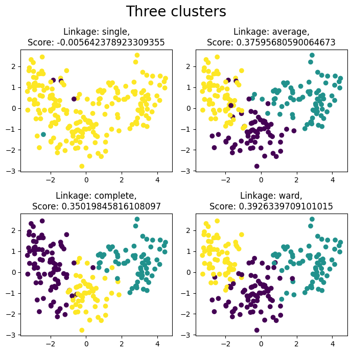

```python
# outline for the plots
fig, axes = plt.subplots(2,2, figsize=(7,7))
fig.suptitle("Three clusters", fontsize=20)

linkage_criteria = ["single", "average", "complete", "ward"]

axes = axes.flatten() # creates a single array from a 2D-matrix

silhoutte_scores = [-0.005642378923309355, 0.37595680590064673, 0.35019845816108097, 0.3926339709101015]

for i, ax in enumerate(axes):
    df = dataframes[i]
    x = df['x']
    y = df['y']
    labels = df['lab']

    ax.scatter(x, y, c=labels)
    ax.set_title(f"Linkage: {linkage_criteria[i]},\nScore: {silhoutte_scores[i]}")

plt.tight_layout()
```

- Similarly, from the clusterings using **'ward'** linkage criterion, plot the four clusterings of best performing **number of clusters** as scatter plots.

```python
#The number of clusters for which 'Ward' linkage performs the best with (i.e. highest silhoutte coefficient)
#is n = 2,3,4,5

#Perform PCA (with 2 components) with 2, 3, 4 and 5 clusters
dataframes = []
for clusters in range(2, 6):
    ward_clustering = AgglomerativeClustering(n_clusters = clusters, linkage = 'ward').fit(seeds_standardized)
    ward_pca = PCA(n_components = 2).fit_transform(seeds_standardized)
    ward_clustering_labels = pd.Series(ward_clustering.labels_)

    ward_clustering_df = pd.DataFrame({
        'x': ward_pca[:, 0],
        'y': ward_pca[:, 1],
        'lab': ward_clustering_labels
    })

    dataframes.append(ward_clustering_df)
print(dataframes)

silhoutte_scores_ward = [0.4612971903388491, 0.3926339709101015, 0.3005761085141328, 0.27463857070040487]
```

```
[            x         y  lab
0    2.787331 -0.676917    1
1   -2.872581  0.251767    0
2   -3.182829  1.927996    0
3    2.345044  0.521664    1
4    0.691521  0.811736    1
..        ...       ...  ...
205 -2.394635 -1.261654    0
206 -1.693995 -0.748661    0
207 -3.206245  1.791829    0
208 -2.025368  0.478935    0
209  3.162834 -0.167412    1

[210 rows x 3 columns],             x         y  lab
0    2.787331 -0.676917    1
```

[output cut: 38 more lines]

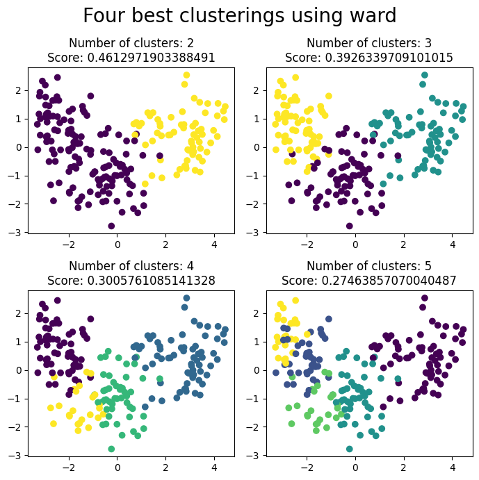

```python
# outline for the plots
fig, axes = plt.subplots(2,2, figsize=(7,7))
fig.suptitle("Four best clusterings using ward", fontsize=20)

axes = axes.flatten() # creates a single array from a 2D-matrix

for i, ax in enumerate(axes):
    df = dataframes[i]
    x = df['x']
    y = df['y']
    labels = df['lab']

    ax.scatter(x, y, c=labels)
    ax.set_title(f"Number of clusters: {i + 2}\nScore: {silhoutte_scores_ward[i]}")

plt.tight_layout()
```

Think about the clusters you see and how the choice of the linkage criterion and the number of clusters affected the formation of clusters. No need to write an answer.

Do some of the clusterings discovered by agglomerative hierarchical clustering correspond to what visually looked like clusters to you in Part 1? Which ones? It's absolutely fine if they don't.

### Part 3: *k*-means clustering

- Perform *k*-means clustering on the standardized data. Try 2-10 numbers of clusters.
- Evaluate the clustering performance using the silhouette coefficient.
- Store the centroids of the clusters

```python
centroids = []

#Perform the kmeans clustering with 2-10 clusters and store centroids in above array
for clusters in range(2, 11):
    kmeans = KMeans(n_clusters = clusters).fit(seeds_standardized)
    kmeans_labels = kmeans.labels_
    kmeans_score = silhouette_score(seeds_standardized, kmeans_labels)
    print(kmeans.cluster_centers_)
    centroids.append(kmeans.cluster_centers_)
    print('Amount of clusters: ' + str(clusters))
    print('Silhoutte coefficient: ' + str(kmeans_score))

#print(centroids)
```

```
[[-0.65880423 -0.66298195 -0.3140631  -0.65190227 -0.61604069  0.08462825
  -0.66398278]
 [ 1.13793459  1.14515065  0.54247263  1.12601301  1.06407029 -0.14617607
   1.14687934]]
Amount of clusters: 2
Silhoutte coefficient: 0.46577247686580914
[[ 1.25368596  1.25895795  0.55912833  1.23493193  1.1620751  -0.04511157
   1.28922727]
 [-0.16161928 -0.19277138  0.44204495 -0.27983662 -0.01900935 -0.65112686
  -0.59705582]
 [-1.03141074 -1.0039696  -0.99615542 -0.89017665 -1.09244785  0.72221051
  -0.61133075]]
Amount of clusters: 3
Silhoutte coefficient: 0.4016230721871724
[[-0.80608756 -0.8537228  -0.10671649 -0.88838344 -0.71310048 -0.33340998
  -0.93984926]
 [ 1.31519805  1.31808105  0.57349823  1.30575236  1.20860652 -0.07230658
   1.34703508]
 [-1.07640452 -1.02864457 -1.21996846 -0.87139738 -1.18390016  1.06312722
  -0.53273025]
 [ 0.04398262  0.03296247  0.47305845 -0.06018701  0.1814737  -0.57678727
  -0.34597119]]
Amount of clusters: 4
Silhoutte coefficient: 0.3106561971980377
[[-1.04991709 -1.01143979 -1.1081809  -0.87306599 -1.14241855  0.8374178
  -0.55327987]
 [ 0.78226047  0.7945996   0.54020639  0.70915346  0.7993567   0.2317387
   0.81677416]
 [-0.59296903 -0.6828073   0.45448716 -0.8315405  -0.37411189 -0.46026591
  -1.06466201]
 [ 1.53142147  1.53179748  0.56514     1.56764595  1.36828296 -0.18842048
   1.55881784]
 [ 0.05634245  0.06983535  0.31900974  0.02235727  0.14536758 -0.83671724
  -0.32097785]]
Amount of clusters: 5
Silhoutte coefficient: 0.2759233792112987
[[-0.8284707  -0.89770267  0.02154606 -0.96694485 -0.6888317  -0.55172048
  -1.0730418 ]
 [ 1.45625907  1.44408414  0.65695353  1.43610724  1.33994144 -0.15041727
   1.45419518]
```

[output cut: 71 more lines]

```
  -0.65423778]
 [-0.19220643 -0.17490304  0.12904486 -0.16370867 -0.12971722 -0.16941338
  -0.63328116]
 [ 0.61445964  0.69288633  0.11256147  0.69094689  0.54632163  0.17980076
   0.83932507]
 [-0.59518502 -0.71959541  0.69088621 -0.91991548 -0.3305218  -0.93109737
  -1.05497573]
 [-1.17998654 -1.03587893 -2.07760902 -0.73074998 -1.47812892  0.99585738
  -0.41210591]
 [-0.64870061 -0.69986254  0.13897006 -0.76128604 -0.46008628  1.38571717
  -0.63268793]
 [ 1.65639756  1.70664622  0.22798459  1.84116368  1.35089454  0.21237827
   1.78610003]]
Amount of clusters: 10
Silhoutte coefficient: 0.2354837930269361
```

- Choose the four best numbers of clusters according to silhouette coefficient that you discovered above.
- Once again visualize them on a scatter plot of the first two principal components.
- Display the centroids of the clusters on the plot.
- Remember to transform the centroids to the PCA space.
- Explain why you need to transform the centroids.

```python
#Transform centroids to 2-dimensional points
cluster_centres_2 = PCA(n_components = 2).fit_transform(centroids[0])
cluster_centres_3 = PCA(n_components = 2).fit_transform(centroids[1])
cluster_centres_4 = PCA(n_components = 2).fit_transform(centroids[2])
cluster_centres_6 = PCA(n_components = 2).fit_transform(centroids[4])

#Transform to dataframes for plotting
cluster_centres_2_df = pd.DataFrame(cluster_centres_2, columns = ['x', 'y'])
cluster_centres_3_df = pd.DataFrame(cluster_centres_3, columns = ['x', 'y'])
cluster_centres_4_df = pd.DataFrame(cluster_centres_4, columns = ['x', 'y'])
cluster_centres_6_df = pd.DataFrame(cluster_centres_6, columns = ['x', 'y'])

cluster_centres_array = [cluster_centres_2_df, cluster_centres_3_df, cluster_centres_4_df, cluster_centres_6_df]
#print(cluster_centres_array)

pca = PCA(n_components = 2).fit_transform(seeds_standardized)

kmeans_2 = KMeans(n_clusters = 2).fit(seeds_standardized)
kmeans_labels_2 = kmeans_2.labels_
kmeans2_df = pd.DataFrame({
    'x': pca[:, 0],
    'y': pca[:, 1],
    'lab': kmeans_labels_2
})

kmeans_3 = KMeans(n_clusters = 3).fit(seeds_standardized)
kmeans_labels_3 = kmeans_3.labels_
kmeans3_df = pd.DataFrame({
    'x': pca[:, 0],
    'y': pca[:, 1],
    'lab': kmeans_labels_3
})

kmeans_4 = KMeans(n_clusters = 4).fit(seeds_standardized)
kmeans_labels_4 = kmeans_4.labels_
kmeans4_df = pd.DataFrame({
    'x': pca[:, 0],
    'y': pca[:, 1],
    'lab': kmeans_labels_4
})

kmeans_6 = KMeans(n_clusters = 6).fit(seeds_standardized)
kmeans_labels_6 = kmeans_6.labels_
kmeans6_df = pd.DataFrame({
    'x': pca[:, 0],
    'y': pca[:, 1],
    'lab': kmeans_labels_6
})

dataframes = [kmeans2_df, kmeans3_df, kmeans4_df, kmeans6_df]
clusters = [2, 3, 4, 6]
silhoutte_coefficients = [0.46577247686580914, 0.4016230721871724, 0.3106561971980377, 0.2882101169533752]
```

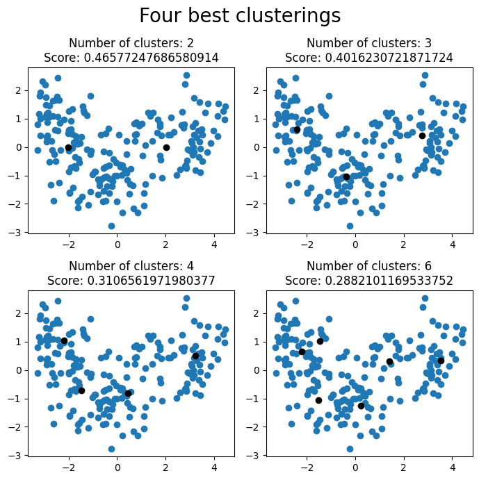

```python
# outline for the plots
fig, axes = plt.subplots(2,2, figsize=(7,7))
fig.suptitle("Four best clusterings", fontsize=20)

axes = axes.flatten() # creates a single array from a 2D-matrix

for i, ax in enumerate(axes):
    df = dataframes[i]
    x = df['x']
    y = df['y']
    labels = df['lab']

    ax.scatter(x, y)

    centres = cluster_centres_array[i]
    centre_x = centres['x']
    centre_y = centres['y']
    ax.scatter(centre_x, centre_y, c = 'black') # centroids
    ax.set_title(f"Number of clusters: {clusters[i]}\nScore: {silhoutte_coefficients[i]}")

plt.tight_layout()
```

### Part 4 (BONUS): Filling in missing labels using clustering

In this bonus exercise, you're given a dataset with almost all of the labels missing. This is the starting point in semi-supervised learning. Semi-supervised learning in general is beyond the scope of this course, but if you want you can learn more about it, starting e.g. on [the sklearn page for semi-supervised learning](https://scikit-learn.org/stable/modules/semi_supervised.html). **This exercise does not require researching semi-supervised learning, however.**

The dataset used in this exercise is a slightly modified version of [the wine dataset](https://archive.ics.uci.edu/dataset/109/wine). The features quantify chemical properties of wine, grown around the same area in Italy. They are divided to three different classes, simply called `1`, `2` and `3` here. The feature names and their data types are listed in the table below. **Use the modified dataset on Moodle, with the filename `wine_missing_labels.csv`**

| Feature | Type | :--- | ---: | Alcohol | Numeric (float) | Malic acid | Numeric (float) | Ash | Numeric (float) | Alcalinity of ash | Numeric (float) | Magnesium | Numeric (integer) | Total phenols | Numeric (float) | Flavanoids | Numeric (float) | Nonflavanoid phenols | Numeric (float) | Proanthocyanins | Numeric (float) | Color intensity | Numeric (float) | Hue | Numeric (float) | OD280/OD315 of diluted wines | Numeric (float) | Proline | Numeric (integer)

First, visualize the first two principal components of the dataset in a scatter plot, showing the labels real for data points you were given. Try to see if the labels look like they belong in what look like clusters on the plot.

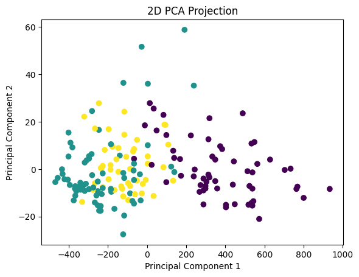

```python
wine_data = pd.read_csv('wine_missing_labels.csv')
wine_labels = pd.read_csv('wine_labels.csv')
wine_data = wine_data.drop('Label', axis = 1)
wine_pca = PCA(n_components = 2).fit_transform(wine_data)

plt.scatter(wine_pca[:, 0], wine_pca[:, 1], c = wine_labels['Label'])
plt.xlabel('Principal Component 1')
plt.ylabel('Principal Component 2')
plt.title('2D PCA Projection')
plt.show()
```

Your task is to use clustering to assign labels to the rows that have a missing value as their label. Do this by first clustering all of the data, and then filling in the missing labels based on which clusters the data points with known labels tend to fit in.

Use whichever clustering methods you prefer. You can cluster the data into 3 clusters because you have 3 known labels, but you could also try a higher number of clusters that you can then merge.

The details of how exactly you decide which rows get assigned which label are up to you - you can get creative. Describe and justify your thought process.

You are also given the full labels for the dataset in a separate file called `wine_labels.csv`. Plot the real labels next to the labels that your clustering attempts predicted.

Finally, compute the adjusted Rand index for labels predicted by your clustering solutions and the real labels, and display it along the scatter plots. Rand index is a measure of similarity between two partitions of a set of elements. Adjusted Rand index is corrected for chance using the maximum and expected values of Rand index. Optionally, you can learn more about the Rand index e.g. on [the Wikipedia page for Rand index](https://en.wikipedia.org/wiki/Rand_index). Here you can simply use the `sklearn.metrics.adjusted_rand_score` method imported at the beginning of this notebook without further understanding of it.

*Hint: you should get something over 0.8*

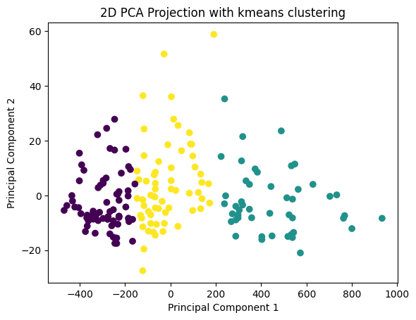

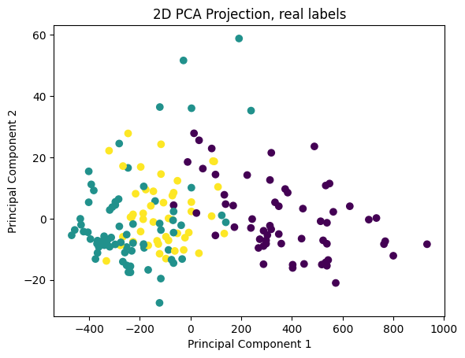

```
Adjusted rand score for kmeans labeling: 0.37111371823084754
```

```python
#Z-score standardization
wine_standardized = (wine_data - wine_data.mean()) / wine_data.std()

#Kmeans clustering
kmeans = KMeans(n_clusters = 3).fit(wine_data)
kmeans_labels = kmeans.labels_

#Plot the predicted labels as well as the real labels
plt.scatter(wine_pca[:, 0], wine_pca[:, 1], c = kmeans_labels)
plt.xlabel('Principal Component 1')
plt.ylabel('Principal Component 2')
plt.title('2D PCA Projection with kmeans clustering')
plt.show()

plt.scatter(wine_pca[:, 0], wine_pca[:, 1], c = wine_labels['Label'])
plt.xlabel('Principal Component 1')
plt.ylabel('Principal Component 2')
plt.title('2D PCA Projection, real labels')
plt.show()

#Compute and display rand score
rand_score = adjusted_rand_score(wine_labels['Label'], kmeans_labels)
print('Adjusted rand score for kmeans labeling: ' + str(rand_score))
```